# R for beginner

Vincent Manzanilla, INTERTRYP, IRD

17 October 2024

# 1 How to install R?

## 1.1 Useful link

To install R, you can go to https://cran.r-project.org/, and download the install file for your favorite operating system, click on the .exe, .dmg, .pkg, .deb, respectively for Windows, MacOS and Linux-debian.

And click on follow… until to reach successful installation Then download and install the IDE Rstudio https://posit.co/download/rstudio-desktop/.

*Everything is free to download*

### 1.1.1 First commands

**Where am I?**

To get the current working directory

```r
getwd()
```

```
## [1] "/home/vincent/Documents/metagenomics_conakry/Day_1/1_R_practical"
```

**To change my working directory from the console**

```r
setwd("/path/to/my/fancy/project/")
```

In Rstudio, we can change the working directory by navigating in folder in **File** panel and clicking on menu **More**

If you are using a Rproject, you don’t need to change your working directory.

**How can I find documentation about function?**

The command `help()` is the 911

```r
# exemple with function read.table
help("read.table")
#other exemple of 911
example("plot")
??plot()
```

# 2 How to use a package?

## 2.1 Installation

You can install new packages by clicking directly in Rstudio or by command line (the best way for me)

```r
install.packages("your_package") # for packages on CRAN mirror
```

For packages from Bioconductor (specifically for bioinformatic):

```r
BiocManager::install("your_package")
```

or from github (using the package devtools)

```r
devtools::install_github("your_package")
```

## 2.2 Using functions from a package

To use functions from a specific package you can either load the entire package:

```r
library("your package1")
library("your package2")
library("your package3")
```

or call the function this way:

```r
your_package::yourfunction()
```

# 3 Expression and affectation

## 3.1 Expression

An expression is directly evaluated and the result is displayed on terminal Example :

```r
2 + 3
```

```
## [1] 5
```

```r
sqrt(25)
```

```
## [1] 5
```

## 3.2 Affectation in an object

An assignment is an expression stored in object or variable. In this example expression, constant, array, matrix, data frame, list Example :

```r
a <- 2 + 3
b <- "bird"
```

**What happens when you execute this cell?**

```r
a
```

```
## [1] 5
```

```r
b
```

```
## [1] "bird"
```

```r
a <- 10
b <- "5"
```

```r
somme <- a + b
```

**Why do we have an error ? I need to know the type of the object**

```r
str(a)
```

```
##  num 10
```

```r
str(b)
```

```
##  chr "5"
```

**What kind of information do we get?**

We can also perform mathematical operations on numerical objects.

```r
log(a) # to obtain the logarithm of a
```

```
## [1] 2.302585
```

```r
sqrt(a)# to obtain the square root of a
```

```
## [1] 3.162278
```

```r
# we can compare it
log(a) > sqrt(a)
```

```
## [1] FALSE
```

## 3.3 Type of objects

### 3.3.1 Vectors

Vectors are objects composed by values with the same type or (i.e, numeric, characters…)

```r
V1 <- c(2, 6, 9) # numeric vector
V2 <- c("monday", "Tuesday", "Wednesday") # character vector
V3 <- rep(6, 3) # repetition of the same value
V4 <- seq(1, 3, 0.1)# sequence of number
V5 <- 1:100
V5
```

```
##   [1]   1   2   3   4   5   6   7   8   9  10  11  12  13  14  15  16  17  18
##  [19]  19  20  21  22  23  24  25  26  27  28  29  30  31  32  33  34  35  36
##  [37]  37  38  39  40  41  42  43  44  45  46  47  48  49  50  51  52  53  54
##  [55]  55  56  57  58  59  60  61  62  63  64  65  66  67  68  69  70  71  72
##  [73]  73  74  75  76  77  78  79  80  81  82  83  84  85  86  87  88  89  90
##  [91]  91  92  93  94  95  96  97  98  99 100
```

To know the number of value inside a vector

```r
length(V1)
```

```
## [1] 3
```

**What do you think about V4?**

Filter a vector according to criteria

```r
# Example : with list of value (a vector)

x <- c(1, 3, 5, 3, 2, 1, 4, 6, 4, 7, 5, 4, 3)

# get element from 2 to 6

x[2:6]
```

```
## [1] 3 5 3 2 1
```

```r
# get elements 3 et 5 from x.

x[c(3, 5)]
```

```
## [1] 5 2
```

```r
# get value more than 20.

x[x > 5]
```

```
## [1] 6 7
```

```r
# get value of  x where x is equal to 21.

x[x == 5]
```

```
## [1] 5 5
```

```r
# return elements form x the the value different from 5

x[x != 5]
```

```
##  [1] 1 3 3 2 1 4 6 4 7 4 3
```

Filter a vector according to several criteria

```r
# 3 lists : ages, sexes et poids

age <- c(20, 30, 40,
         15, 22, 24,
         36, 38)

sexe <- c("F", "M", "F",
          "M", "F", "M",
          "F", "M")

poids <- c(75, 76, 73,
           72, 64, 76,
           73, 72)

# get value from age greater than 20 and less than 30.

age[age > 20 & age < 30]
```

```
## [1] 22 24
```

```r
# Recovering "poids" for those who are older than 25 and female

poids[age > 25 & sexe == "F"]
```

```
## [1] 73 73
```

```r
#Retrieve age values below 20 or above 30.

age[age < 20 | age > 30]
```

```
## [1] 40 15 36 38
```

*Exo1*

Considering the vector `a` such as `a <- c("lannister", "targaryen", "baratheon", "starck", "greyjoy")`

1. What is the length of the vector?
2. Try doing `a[1:3]`. What do you get?
3. Create a new vector b containing only lannister and starck.
4. Try doing `a[-1]`. What do you get?
5. Sort by alphabetical order using `sort()`

*Exo2*

1. Create a vector `a` containing all integers from 1 to 100.
2. Add the values 200, 201, 202 to the vector `a`.
3. Create a vector `b` containing all even integers from 2 to 100 using `seq()`

### 3.3.2 Data frames

Data frames are objects composed by vector where the value are of different modes (i.e, numeric, characters…)

#### 3.3.2.1 Data frame examples

Load a data frame

```r
data(iris)
```

Visualise the data frame in a table

```r
View(iris)
```

Display its internal structure

```r
str(iris)
```

```
## 'data.frame':    150 obs. of  5 variables:
##  $ Sepal.Length: num  5.1 4.9 4.7 4.6 5 5.4 4.6 5 4.4 4.9 ...
##  $ Sepal.Width : num  3.5 3 3.2 3.1 3.6 3.9 3.4 3.4 2.9 3.1 ...
##  $ Petal.Length: num  1.4 1.4 1.3 1.5 1.4 1.7 1.4 1.5 1.4 1.5 ...
##  $ Petal.Width : num  0.2 0.2 0.2 0.2 0.2 0.4 0.3 0.2 0.2 0.1 ...
##  $ Species     : Factor w/ 3 levels "setosa","versicolor",..: 1 1 1 1 1 1 1 1 1 1 ...
```

**What can we notice?**

#### 3.3.2.2 How to build your own data frame

```r
date <- c("1_monday", "2_Tuesday", "3_Wednesday",
          "4_Thursday", "5_Friday", "6_Sturday",
          "7_Sunday")

is.character(date)
```

```
## [1] TRUE
```

```r
# temperature in deg Celsius
temperature <- c(24, 27, 25,
               22, 30, 21,
               28)

is.numeric(temperature)
```

```
## [1] TRUE
```

```r
# rain in mm
rain <- c(1, 0, 0,
          5, 2, 0,
          0)

is.numeric(rain)
```

```
## [1] TRUE
```

```r
# make data.frame
df <- data.frame(date, temperature, rain)
str(df)
```

```
## 'data.frame':    7 obs. of  3 variables:
##  $ date       : chr  "1_monday" "2_Tuesday" "3_Wednesday" "4_Thursday" ...
##  $ temperature: num  24 27 25 22 30 21 28
##  $ rain       : num  1 0 0 5 2 0 0
```

```r
#To select a column or vector
df$temperature
```

```
## [1] 24 27 25 22 30 21 28
```

```r
df[, 2]
```

```
## [1] 24 27 25 22 30 21 28
```

```r
# here we use list() instead of c()
# because there is multiple class in inside row

day <- list("8_monday", 29, 1)
new_def <- rbind(df, day)# add row to a data frame
new_def
```

```
##          date temperature rain
## 1    1_monday          24    1
## 2   2_Tuesday          27    0
## 3 3_Wednesday          25    0
## 4  4_Thursday          22    5
## 5    5_Friday          30    2
## 6   6_Sturday          21    0
## 7    7_Sunday          28    0
## 8    8_monday          29    1
```

# 4 Functions

## 4.1 Definition

Function are a compilation of command line with different instructions inside one object to simplify code. A function is composed by **arguments** and **options**.

function(argument1, argument2, option1, … ,option10)

## 4.2 Usual functions for data frame

```r
head() # to know first line of your data frame
class()# return the class of the object. Ex : data.frame, matrix, list ....
str()# return the structure of the object. Ex : numeric, factor, character....
names()# to get or set the names of an object
sum() # for addition
min() # return the minimum of the vector
max() # return the minimum of the vector
row.names() # attribute names for lines of the data frame
colnames() # attribute names for column of the data frame
apply() # Returns a vector or array or list of values obtained by applying a function to margins of an array or matrix.
```

**Example function row.names, class and str**

```r
df2 <- data.frame(x = c(TRUE, FALSE, NA, NA), y = c(12, 34, 56, 78))
df2
```

```
##       x  y
## 1  TRUE 12
## 2 FALSE 34
## 3    NA 56
## 4    NA 78
```

```r
row.names(df2) <- paste("row", 1 : 4, sep = "_")
df2 # what do you see
```

```
##           x  y
## row_1  TRUE 12
## row_2 FALSE 34
## row_3    NA 56
## row_4    NA 78
```

```r
class(df2)
```

```
## [1] "data.frame"
```

```r
str(df2)
```

```
## 'data.frame':    4 obs. of  2 variables:
##  $ x: logi  TRUE FALSE NA NA
##  $ y: num  12 34 56 78
```

**Example function apply**

```r
head(df)
```

```
##          date temperature rain
## 1    1_monday          24    1
## 2   2_Tuesday          27    0
## 3 3_Wednesday          25    0
## 4  4_Thursday          22    5
## 5    5_Friday          30    2
## 6   6_Sturday          21    0
```

```r
class(df)
```

```
## [1] "data.frame"
```

```r
str(df)
```

```
## 'data.frame':    7 obs. of  3 variables:
##  $ date       : chr  "1_monday" "2_Tuesday" "3_Wednesday" "4_Thursday" ...
##  $ temperature: num  24 27 25 22 30 21 28
##  $ rain       : num  1 0 0 5 2 0 0
```

```r
# return mean for the numerical column of the data.frame. apply(data,margin,fun).
# For margin parameter the value 1 return mean for each row,
# for margin=2 return mean for each selected column.
apply(df[, 2:3], 2, mean)
```

```
## temperature        rain
##   25.285714    1.142857
```

*Exo 3*

**From data set iris in package** datasets** Load package datasets and load data set iris using `data()`

1. Give the class Sepal.Width and Species vectors
2. What is the minimum / maximum / average sepal length of these irises?
3. What are the values of the first 10 irises?
4. Calculate standard deviation for every numeric vector (function : `sd()`)
5. Calculate mean for every numeric vector
6. Create a data frame with mean and sd as line and give a name for each line
7. An error of 0.5cm was made in the measurement of the length of the sepal of the 41st iris: add 0.5cm to this measurement

## 4.3 Use dplyr to select, filter a data frame

`dplyr` is part of the library set named `tidyverse` (contraction of “tidy” and “universe”, it’s a tidy universe). `tidyverse` packages are designed to work together and thus follow the same code logic and a common grammar.

The pipe, `%>%`, is one of the useful elements of the tidyverse. It allows to structure sequences of operations by minimizing the creation of intermediate objects and by facilitating the addition of a step anywhere in this sequence. Note that from R 4.1 you can use a new pipe, `|>` without the need of loading any library.

The most commonly used tidyverse packages are loaded in your session:

- [`ggplot2`](https://github.com/rstudio/cheatsheets/blob/main/data-visualization.pdf)
- [`dplyr`](https://github.com/rstudio/cheatsheets/blob/main/data-transformation.pdf)
- [`tidyr`](https://github.com/rstudio/cheatsheets/blob/main/tidyr.pdf)
- [`readr`](https://raw.githubusercontent.com/rstudio/cheatsheets/main/data-import.pdf)
- [`tibble`](https://r4ds.had.co.nz/tibbles.html)
- [`stringr`](https://github.com/rstudio/cheatsheets/blob/main/strings.pdf)

```r
tidyverse::tidyverse_packages()
```

```
##  [1] "broom"         "conflicted"    "cli"           "dbplyr"
##  [5] "dplyr"         "dtplyr"        "forcats"       "ggplot2"
##  [9] "googledrive"   "googlesheets4" "haven"         "hms"
## [13] "httr"          "jsonlite"      "lubridate"     "magrittr"
## [17] "modelr"        "pillar"        "purrr"         "ragg"
## [21] "readr"         "readxl"        "reprex"        "rlang"
## [25] "rstudioapi"    "rvest"         "stringr"       "tibble"
## [29] "tidyr"         "xml2"          "tidyverse"
```

#### 4.3.0.1 Filter and select variable in data frame

```r
library(tidyverse)
data("iris")
#To select a variable with tidyverse
dplyr::select(iris, Species)
```

```
##        Species
## 1       setosa
## 2       setosa
## 3       setosa
## 4       setosa
## 5       setosa
## 6       setosa
## 7       setosa
## 8       setosa
## 9       setosa
## 10      setosa
## 11      setosa
## 12      setosa
## 13      setosa
## 14      setosa
```

[output cut: 136 more lines]

```r
#To select several variables with tidyverse
dplyr::select(iris,Species, Sepal.Length, Sepal.Width)
```

```
##        Species Sepal.Length Sepal.Width
## 1       setosa          5.1         3.5
## 2       setosa          4.9         3.0
## 3       setosa          4.7         3.2
## 4       setosa          4.6         3.1
## 5       setosa          5.0         3.6
## 6       setosa          5.4         3.9
## 7       setosa          4.6         3.4
## 8       setosa          5.0         3.4
## 9       setosa          4.4         2.9
## 10      setosa          4.9         3.1
## 11      setosa          5.4         3.7
## 12      setosa          4.8         3.4
## 13      setosa          4.8         3.0
## 14      setosa          4.3         3.0
```

[output cut: 136 more lines]

```r
# To select several lines inside data frame
dplyr::slice(iris, 22:30)
```

```
##   Sepal.Length Sepal.Width Petal.Length Petal.Width Species
## 1          5.1         3.7          1.5         0.4  setosa
## 2          4.6         3.6          1.0         0.2  setosa
## 3          5.1         3.3          1.7         0.5  setosa
## 4          4.8         3.4          1.9         0.2  setosa
## 5          5.0         3.0          1.6         0.2  setosa
## 6          5.0         3.4          1.6         0.4  setosa
## 7          5.2         3.5          1.5         0.2  setosa
## 8          5.2         3.4          1.4         0.2  setosa
## 9          4.7         3.2          1.6         0.2  setosa
```

```r
# I can affect it to an object

subdata <- dplyr::slice(iris, 22:30)

#or choosing different lines
myline <- c(22, 38, 120) # I build a vector containing the line that I want
dplyr::slice(iris,myline)
```

```
##   Sepal.Length Sepal.Width Petal.Length Petal.Width   Species
## 1          5.1         3.7          1.5         0.4    setosa
## 2          4.9         3.6          1.4         0.1    setosa
## 3          6.0         2.2          5.0         1.5 virginica
```

#### 4.3.0.2 Bonus : to pipe many function serval function together

The pipe **|>** , or **%>%**, is one of the useful elements of the tidyverse. It allows to structure sequences of operations by minimizing the creation of intermediate objects and by facilitating the addition of a step anywhere in this sequence.

The useful command to manage data frame : 1) select() to select vector or variable from a data frame ; 2) filter() is used to subset a data frame, retaining all rows that satisfy your conditions ; mutate() adds new variables and preserves existing ones.

```r
library(dplyr)

df1 <- iris %>%
  filter(Sepal.Length > 6) %>% # filtered using size of Sepal Length
  filter(Species == "versicolor") # and the species
nrow(df1)
```

```
## [1] 20
```

```r
dim(df1)
```

```
## [1] 20  5
```

```r
iris %>%
  select(Sepal.Length, Species) %>%
  mutate(Sepal.Length2 = Sepal.Length * 2) %>%
  mutate(Sepal.Length2_squared = Sepal.Length2 * Sepal.Length2)
```

```
##     Sepal.Length    Species Sepal.Length2 Sepal.Length2_squared
## 1            5.1     setosa          10.2                104.04
## 2            4.9     setosa           9.8                 96.04
## 3            4.7     setosa           9.4                 88.36
## 4            4.6     setosa           9.2                 84.64
## 5            5.0     setosa          10.0                100.00
## 6            5.4     setosa          10.8                116.64
## 7            4.6     setosa           9.2                 84.64
## 8            5.0     setosa          10.0                100.00
## 9            4.4     setosa           8.8                 77.44
## 10           4.9     setosa           9.8                 96.04
## 11           5.4     setosa          10.8                116.64
## 12           4.8     setosa           9.6                 92.16
## 13           4.8     setosa           9.6                 92.16
## 14           4.3     setosa           8.6                 73.96
```

[output cut: 136 more lines]

```r
iris %>%
  select(Sepal.Length, Species) %>%
  mutate(Sepal.Length = Sepal.Length / mean(Sepal.Length, na.rm = TRUE))
```

```
##     Sepal.Length    Species
## 1      0.8727895     setosa
## 2      0.8385625     setosa
## 3      0.8043354     setosa
## 4      0.7872219     setosa
## 5      0.8556760     setosa
## 6      0.9241301     setosa
## 7      0.7872219     setosa
## 8      0.8556760     setosa
## 9      0.7529949     setosa
## 10     0.8385625     setosa
## 11     0.9241301     setosa
## 12     0.8214489     setosa
## 13     0.8214489     setosa
## 14     0.7358813     setosa
```

[output cut: 136 more lines]

```r
#Sepal.Length_norm is calculated using the mean of the Sepal.Length for all data set.

iris %>%
  select(Sepal.Length, Species) %>%
  group_by(Species) %>%
  mutate(Sepal.Length_norm = Sepal.Length / mean(Sepal.Length, na.rm = TRUE))
```

```
## # A tibble: 150 × 3
## # Groups:   Species [3]
##    Sepal.Length Species Sepal.Length_norm
##           <dbl> <fct>               <dbl>
##  1          5.1 setosa              1.02
##  2          4.9 setosa              0.979
##  3          4.7 setosa              0.939
##  4          4.6 setosa              0.919
##  5          5   setosa              0.999
##  6          5.4 setosa              1.08
##  7          4.6 setosa              0.919
##  8          5   setosa              0.999
##  9          4.4 setosa              0.879
## 10          4.9 setosa              0.979
## # ℹ 140 more rows
```

```r
# In this last example Sepal.Length_norm is calculated using the mean of the Sepal.Length for each species using group_by()
```

**These commands are non-persistent, no changes are made on the original iris data frame.** **If you want to store it, you must assign your changes to a object**

```r
iris_modif <- iris %>%
  select(Sepal.Length, Species) %>%
  group_by(Species) %>%
  mutate(Sepal.Length_norm = Sepal.Length / mean(Sepal.Length, na.rm = TRUE))
```

### 4.3.1 How to import external data frame issue from .txt or .csv

To import data set, the function `read.table()` or `read.csv()` are commonly used.

`read.table(file, header = FALSE, sep = "", dec = ".", ...)`

The main parameter are :

- **file** : add the pathway and the name of the file
- **header** : a logical value (TRUE or FALSE) indicating whether the file contains the names of the variables as its first line.
- **sep** : the field separator character. Values on each line of the file are separated by this character. If sep = “” (the default for read.table) the separator is ‘white space’, that is one or more spaces, tabs, newlines or carriage returns.
- **dec** : the character used in the file for decimal points.

```r
ds <- readxl::read_excel("../../data/Glossina_metadata.xlsx")

ds
```

```
## # A tibble: 78 × 6
##    Sample     spp   sex   `Ecological gradient` Caracteristic Gradie…¹ infection
##    <chr>      <chr> <chr> <chr>                 <chr>                  <chr>
##  1 GI-103_SEC Glos… F     ecotone               mangrove periphery     infected
##  2 GI-59_SEC  Glos… F     ecotone               mangrove periphery     infected
##  3 GI-104_SEC Glos… M     ecotone               mangrove periphery     infected
##  4 GI-111_SEC Glos… F     ecotone               mangrove periphery     infected
##  5 GI-121_SEC Glos… M     ecotone               mangrove periphery     infected
##  6 GI-124_RUR Glos… F     urban                 rural with animals     infected
##  7 GI-125_CUL Glos… F     farmed land           rice, palm trees at m… infected
##  8 GI-14_CUL  Glos… M     farmed land           rice, palm trees at m… not infe…
##  9 GI-15_CUL  Glos… F     farmed land           rice, palm trees at m… infected
## 10 GI-16_RUR  Glos… F     urban                 rural with animals     infected
## # ℹ 68 more rows
## # ℹ abbreviated name: ¹`Caracteristic Gradient`
```

Why I use the parameter `header=TRUE` ?

### 4.3.2 To export data set as .txt to read in excel

The function is similar to `read.table()`

`write.table(x, file = "", sep = " ",na = "NA", dec = ".", ... )`

- **x** : this is your data.frame
- **file** : give a name for your file
- **sep** : cf read.table
- **dec** : cf read.table
- **na** : give a symbole for missing data, by convention is NA

```r
write.table(ds, "ds.txt", sep = "\t", dec = ".")
```

To keep our working directory tidy, we now delete `ds.txt`

```r
file.remove("ds.txt")
```

```
## [1] TRUE
```

Exo 4

1. In the dataset Iris select Sepal Width, Sepal length and Species,to create a new data frame name “subset_iris”
2. Save this new data frame as text file

# 5 How to represent your data

**ggplot2** is a powerfull packages to make a very smart graph “ready to use” for publication. **gg** means grammar and graph, a concept which describe a graph using grammar. This package belong to tidyverse according to `dplyr`. According to the ggplot2 concept, a graph can be divided into different basic parts:**Plot = data + Aesthetics + Geometry**

- *data* : data frame
- *aesthetics* : allows to indicate the x and y variables. It can also be used to control the color, size and shape of the points, etc…
- *geometry* : corresponds to the type of graph (histogram, box plot, line plot, …..)

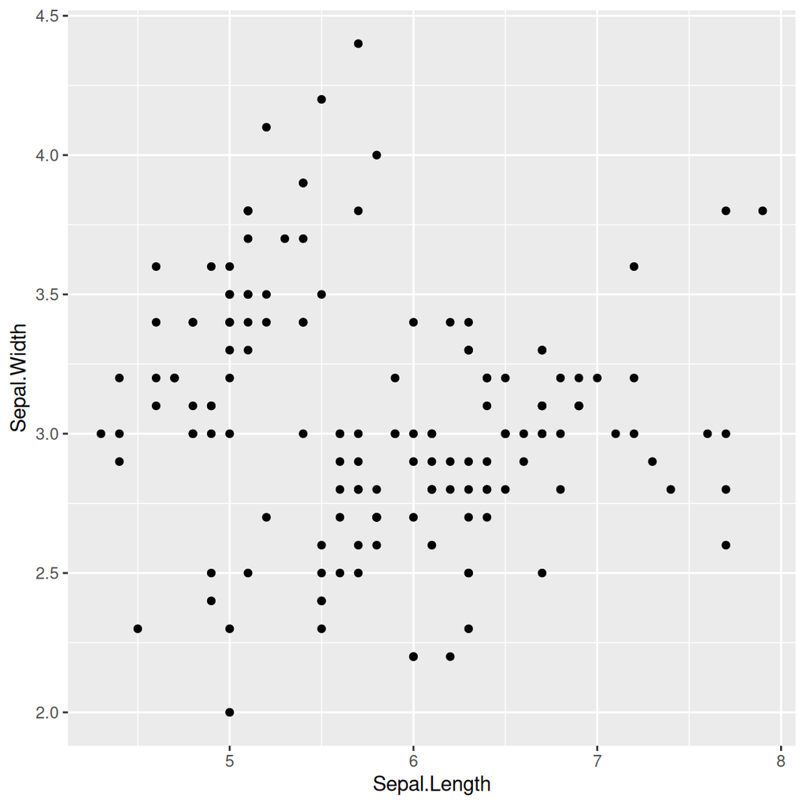

```r
library(ggplot2)
# scatter plot
ggplot(data = iris, aes(Sepal.Length, Sepal.Width)) + #  what I want to represent
  geom_point() # how I represent it
```

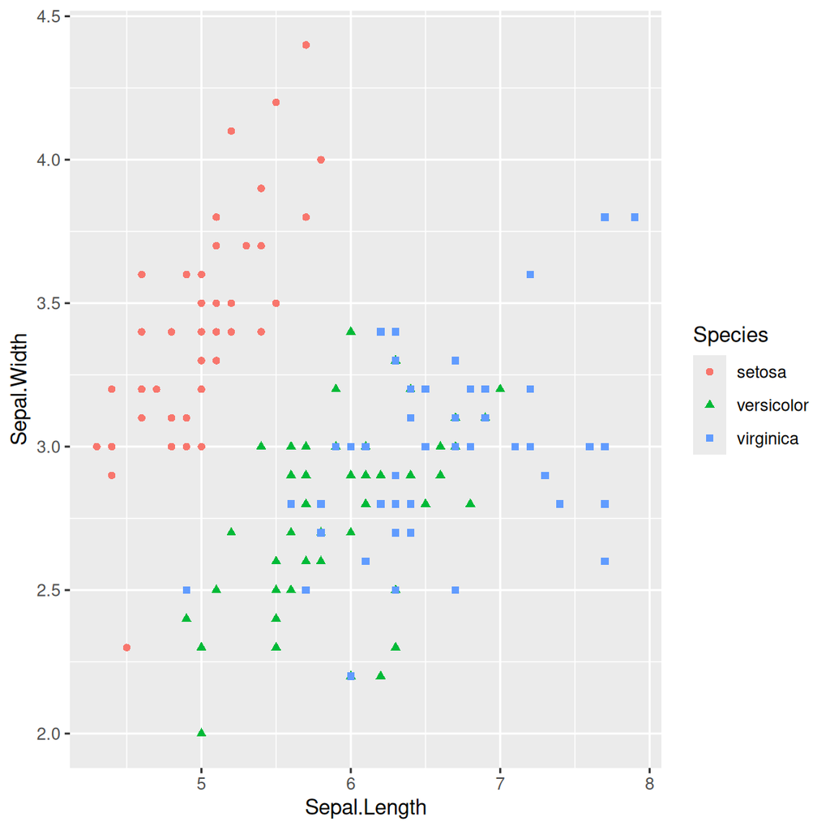

```r
# We can calorize and give a shape by month
# scatter plot
ggplot(data = iris, aes(Sepal.Length, Sepal.Width)) +
  geom_point(aes(color = Species, shape = Species)) # shape is the same thing with classical plot on R
```

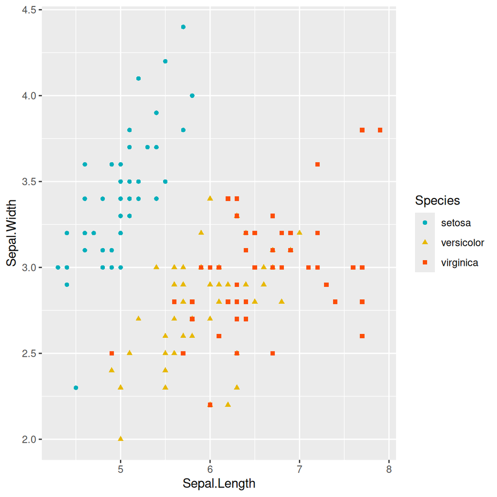

```r
# You can change manually color with la fonction scale_color_manual()
ggplot(data = iris, aes(Sepal.Length, Sepal.Width)) +
  geom_point(aes(color = Species, shape = Species)) +
  scale_color_manual(values = c("#00AFBB", "#E7B800", "#FC4E07"))
```

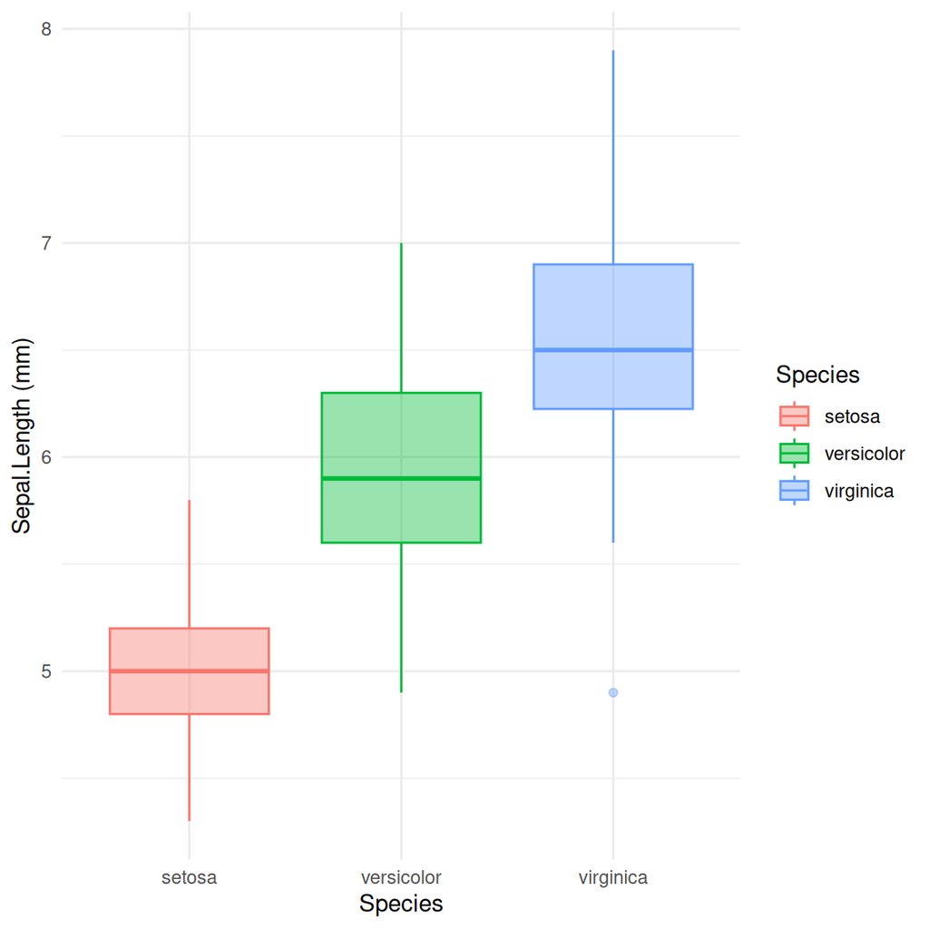

```r
#Boxplot
ggplot(data = iris, aes(Species, Sepal.Length)) + #  what I want to represent
  geom_boxplot(aes(color = Species, fill = Species), alpha=0.4) + # how I represent it. Here I changed geometry using boxplot.
  labs(x ="Species", y = "Sepal.Length (mm)") +
  theme_minimal()
```

**Save your plot**

Using the function `pdf()`

Firstly you have to store plot inside and object

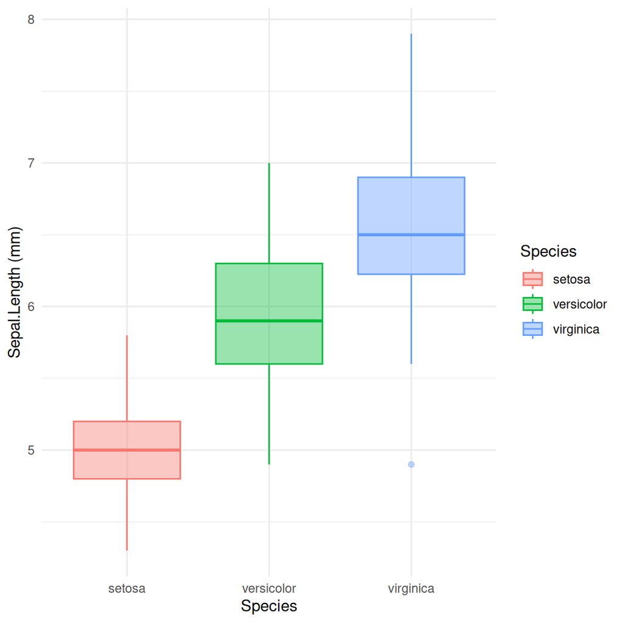

```r
#Boxplot
g1 <- ggplot(data = iris, aes(Species, Sepal.Length)) + #  what I want to represent
  geom_boxplot(aes(color = Species, fill = Species), alpha = 0.4) +# how I represent it. Here I changed geometry using boxplot.
  labs(x = "Species", y = "Sepal.Length (mm)") +
  theme_minimal()
g1
```

```r
pdf("yourfile.pdf")
g1
dev.off()
```

or `ggplot2::ggsave()`

```r
ggsave("~/yourfile2.png", g1)
```